# Report on DQN

```python
# Set up
%matplotlib inline
from IPython.display import clear_output
import dqn
```

## Training with image pixel input

The network is designed to have 3 convolutional layers (with batch normalization and relu), and 1 fully connected layer.

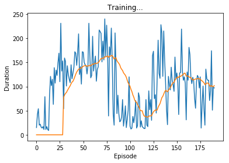

```python
# image pixel input
dqn.args.image = True
dqn.args.batch_size = 128
dqn.args.gamma = 0.999
dqn.main(dqn.args)
```

The training yields rewards over 150 in less than 200 epochs. The training is rather time-consuming, and it takes quite long time to recover from a descending direction in exploration.

## Training with state vector input

The network is designed to have 3 fully connected layers (with batch normalization and relu).

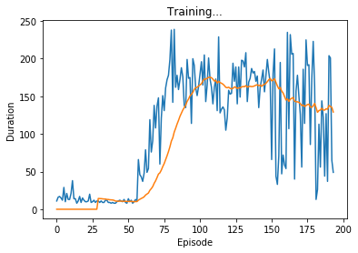

```python
# state vetor input
dqn.args.image = False
dqn.args.batch_size = 128
dqn.args.gamma = 0.85
dqn.main(dqn.args)
```

The training yields better result while significantly more efficient than that with image pixel input, as the input data capture mian infomation with only 4 variables, so the parameters to be trained is far less and the training is easier. This comparison demonstrates the importance of data reduction.

In addition, it is notable that with less input variables, the discount $\gamma$ should be smaller than that with image pixel input (less than 0.9). Otherwise, the training gets stuck on existing experience and fails to update the policy due to lack of flexibility.

For codes, refers to github file https://github.com/Alice86/DeepLearning/blob/master/3_CONVnet%20and%20RESnet%20from%20scrapt;%20DQN%20for%20carpole%20/problem2/dqn.py